```r
# I load the needed libraries
library(dplyr)
library(scales)
library(ggplot2)
```

# Exercise 1

The number of claims received by an insurance company during a week follows a Poisson distribution with unknown mean $(\mu)$. The number of claims, per week, observed over a ten week period are: $$5, 8, 4, 6, 11, 6, 6, 5, 6, 4$$

(a) suppose to use a prior uniform distribution for μ

- find the posterior distribution for μ and compute the posterior mean, median and variance
- plot the posterior distribution and the 95% credibility interval

(b) suppose to use a Jeffreys’ prior for $\mu$: $$g(\mu) \propto \frac{1}{\sqrt{\mu}}$$

- find the posterior distribution for μ and compute the posterior mean, median and variance
- plot the posterior distribution and the 95% credibility interval

(c) evaluate a 95% credibility interval for the results obtained with both priors. Compare the result with that obtained using a normal approximation for the posterior distribution, with the same mean and standard deviation

```r
# Load the data presented:
data = c(5, 8, 4, 6, 11, 6, 6, 5, 6, 4)

# And define the standard plot output
options(repr.plot.width=20, repr.plot.height=8)

# Credibility Interval
CI = 0.95
CI_range = c((1-CI)/2, 1-(1-CI)/2)
```

$\bold{a)}$ I suppose to havce a uniform prior distribution, which means that the posterior is:

$$ \mathbb{P}(\mu | \{y_j\}) \propto \mu^{\sum y_j} e^{-n \mu} = \text{Gamma} \left( \alpha = \sum y_j +1, \lambda = n\right) $$

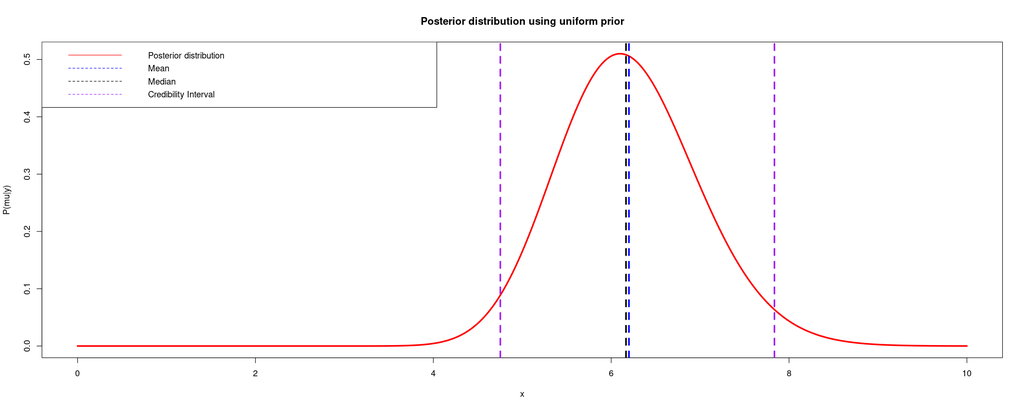

```r
# I define then the parameters of the distribution
alpha = sum(data) + 1
lambda = length(data)

# Using the analytucal function (retrieved from theory) I find the parameters of the posterior
unif_mean = alpha/lambda
unif_median = qgamma(0.5, shape = alpha, rate = lambda)
unif_variance = alpha/(lambda**2)
unif_quant = qgamma(CI_range, shape = alpha, rate = lambda)
unif_results = c("Uniform", paste0("Gamma(", alpha, ",", lambda, ")"), round(unif_mean, 3), round(unif_median, 3), round(sqrt(unif_variance), 3),
                 paste0("[", round(unif_quant[1], 3), ", ", round(unif_quant[2], 3), "]"))


# Plotting the distribution in the required interval
x = seq(0, 10, 0.001)
unif_post = dgamma(x = x, shape = alpha, rate = lambda)
plot(x, unif_post, type = 'l', lwd = 3, col = 'red', xlab = 'x', ylab = 'P(mu|y)', main = 'Posterior distribution using uniform prior')
abline(v = unif_mean, col = 'blue', lty = 2, lwd = 3)
abline(v = unif_median, col = 'black', lty = 2, lwd = 3)
abline(v = unif_quant, col = 'purple', lty = 2, lwd = 3)
legend(x = 'topleft', legend=c("Posterior distribution", "Mean", "Median", "Credibility Interval"), lty = c(1, 2, 2, 2), col=c("red", "blue", "black", "purple"))
```

$\bold{b)}$ Now I suppose to have a Jeffrey's prior distribution, which means that the posterior is:

$$ \mathbb{P}(\mu | \{y_j\}) \propto \mu^{\sum y_j - \frac{1}{2}} e^{-n \mu} = \text{Gamma} \left( \alpha = \sum y_j + \frac{1}{2}, \lambda = n\right) $$

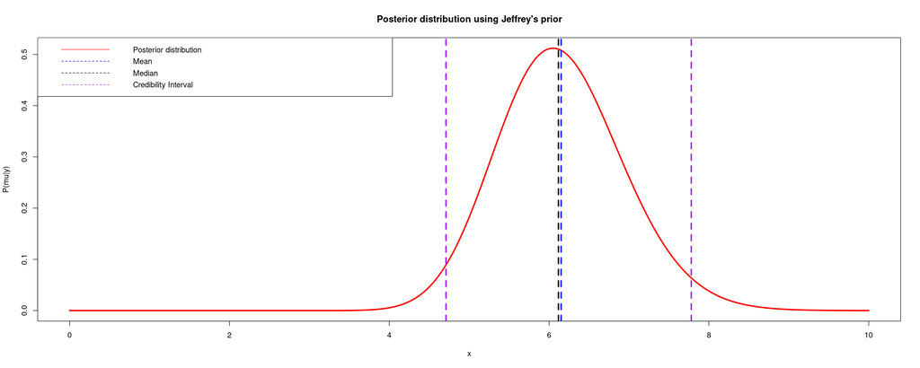

```r
# Same code as before with different parameters
alpha = sum(data) + 0.5
lambda = length(data)

# Using the analytucal function (retrieved from theory) I find the parameters of the posterior
jeff_mean = alpha/lambda
jeff_median = qgamma(0.5, shape = alpha, rate = lambda)
jeff_variance = alpha/(lambda**2)
jeff_quant = qgamma(CI_range, shape = alpha, rate = lambda)
jeff_results = c("Jeffrey", paste0("Gamma(", alpha, ",", lambda, ")"), round(jeff_mean, 3), round(jeff_median, 3), round(sqrt(jeff_variance), 3),
                 paste0("[", round(jeff_quant[1], 3), ", ", round(jeff_quant[2], 3), "]"))


# Plotting the distribution in the required interval
x = seq(0, 10, 0.001)
jeff_post = dgamma(x = x, shape = alpha, rate = lambda)
    plot(x, jeff_post, type = 'l', lwd = 3, col = 'red', xlab = 'x', ylab = 'P(mu|y)', main = "Posterior distribution using Jeffrey's prior")
abline(v = jeff_mean, col = 'blue', lty = 2, lwd = 3)
abline(v = jeff_median, col = 'black', lty = 2, lwd = 3)
abline(v = jeff_quant, col = 'purple', lty = 2, lwd = 3)
legend(x = 'topleft', legend=c("Posterior distribution", "Mean", "Median", "Credibility Interval"), lty = c(1, 2, 2, 2), col=c("red", "blue", "black", "purple"))
```

$\bold{c)}$ In the end I compute a normal approximation for the posterior, following the theoretical approach. Since the two previous approaches give a similar result, I expect the normal approximations to be very similar, using the approximations:

```r
# I have now to perform a normal approximation on the previous distributions using directly the theory
unif_gauss = dnorm(x = x, mean = unif_mean, sd = sqrt(unif_variance))
jeff_gauss = dnorm(x = x, mean = jeff_mean, sd = sqrt(jeff_variance))

unif_gauss_results = c("Uniform",
                        paste0("Norm(", round(unif_mean, 3), ",", round(sqrt(unif_variance), 3), ")"),
                        round(unif_mean, 3),
                        round(unif_mean, 3),
                        round(sqrt(unif_variance), 3),
                        paste0("[", round(qnorm(CI_range[1], mean = unif_mean, sd = sqrt(unif_variance)), 3), ", ",
                        round(qnorm(CI_range[2], mean = unif_mean, sd = sqrt(unif_variance)), 3), "]"))
jeff_gauss_results = c("Jeffrey",
                        paste0("Norm(", round(jeff_mean, 3), ",", round(sqrt(jeff_variance), 3), ")"),
                        round(jeff_mean, 3),
                        round(jeff_mean, 3),
                        round(sqrt(jeff_variance), 3),
                        paste0("[", round(qnorm(CI_range[1], mean = jeff_mean, sd = sqrt(jeff_variance)), 3), ", ",
                        round(qnorm(CI_range[2], mean = jeff_mean, sd = sqrt(jeff_variance)), 3), "]"))

# One could have used also the numerical approach, by evaluating the mean squared error
```

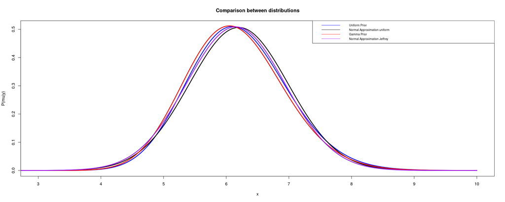

```r
# I collect the three distributions into a unique plot in order to confront them
plot(x, unif_post, type = 'l', lwd = 3, col = 'blue', xlab = 'x', ylab = 'P(mu|y)', xlim = c(3, 10), main = 'Comparison between distributions')
points(x, unif_gauss, type = 'l', lwd = 3, col = 'black')
points(x, jeff_post, type = 'l', lwd = 3, col = 'red')
points(x, jeff_gauss, type = 'l', lwd = 3, col = 'purple')

legend(x = 'topright', legend=c("Uniform Prior", "Normal Approximation uniform", "Gamma Prior", "Normal Approximation Jeffrey"),
       lty = c(1, 1, 1, 1), col=c("blue", "black", "red", "purple"), cex = 0.7)
```

```r
# And, to collect all the data over the three distributions I create a dataframe
df = matrix(c(unif_results, unif_gauss_results, jeff_results, jeff_gauss_results), nrow=4, byrow=TRUE)
colnames(df) <- c('Prior','Posterior','Mean', 'Median', 'Error', 'CI')
df = as.data.frame(df)

df
```

A data.frame: 4 × 6

| Prior <chr> | Posterior <chr> | Mean <chr> | Median <chr> | Error <chr> | CI <chr> |
| --- | --- | --- | --- | --- | --- |
| Uniform | Gamma(62,10) | 6.2 | 6.167 | 0.787 | [4.754, 7.836] |
| Uniform | Norm(6.2,0.787) | 6.2 | 6.2 | 0.787 | [4.657, 7.743] |
| Jeffrey | Gamma(61.5,10) | 6.15 | 6.117 | 0.784 | [4.71, 7.779] |
| Jeffrey | Norm(6.15,0.784) | 6.15 | 6.15 | 0.784 | [4.613, 7.687] |

From both the plot and the table it is visible that the two posteriors and their normal approximations are very similar one to the other: this means that 10 data are enough to present a solid statistics, known the likelihood (Poissonian in this case)

# Exercise 2

A well established and diffused method for detecting a disease in blood fails to detect the presence of disease in 15% of the patients that actually have the disease. A young UniPD startUp has developed an innovative method of screening. During the qualification phase, a random sample of n = 75 patients known to have the disease is screened using the new method.

- what is the probability distribution of y, the number of times the new method fails to detect the disease ?
- on the n = 75 patients sample, the new method fails to detect the disease in y = 6 cases. What is the frequentist estimator of the failure probability of the new method ?
- setup a bayesian computation of the posterior probability, assuming a beta distribution with mean value 0.15 and standard deviation 0.14. Plot the posterior distribution for y, and mark on the plot the mean value and variance
- Perform a test of hypothesis assuming that if the probability of failing to the detect the desease in ill patients is greater or equal than 15%, the new test is no better that the traditional method. Test the sample at a 5% level of significance in the Bayesian way.
- Perform the same hypothesis test in the classical frequentist way

```r
# Data of the problem: failure of the test, number of patients
failure_rate = 0.15; n = 75
```

$\bold{a)}$ Since the phenomenon prevedes a yes/no answer (binary outcome), it must be a Bernoulli process. This means that the distribution of probability is a binomial with $n = 75$ events and a probability of `failure_rate` $= 0.15$ of receiving a negative result even thoug having the disease.

```
The probability distribution is binomial
The old test fails 11 times
```

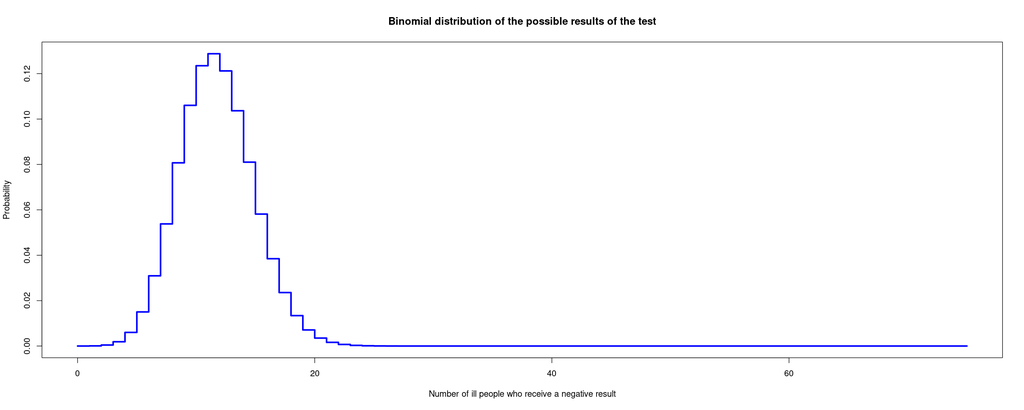

```r
# The probability is binomial
x = seq(from = 0, to = n, by = 1)
binomial = dbinom(x = x, size = n, prob = failure_rate)

# And the number of times that the new test fails to detect the disease is the expected value of the distribution
number_fails = sum(x*binomial)
# Here I stress the fact that from theory it is exactly like evaluating:
# number_fails = failure_rate*n

# Results
cat("The probability distribution is binomial\n")
cat("The old test fails", floor(number_fails), "times")
plot(x, binomial, type = 's', lwd = 3, col = 'blue', xlim = c(0, n), xlab = 'Number of ill people who receive a negative result',
        ylab = 'Probability', main = 'Binomial distribution of the possible results of the test')
```

$\bold{b)}$ The estimators for the frequentist probability are from theory:

$$p_F = \frac{y}{n} $$$$\text{E}\left[p_F\right] = p $$$$\text{Var}\left[p_F\right] = \frac{p \left(1-p\right)}{n} $$$$\text{MSE}\left[p_F\right] = \text{Bias}\left[p_F, p\right]^2 + \text{Var}\left[p_F\right] = \frac{p \left(1-p\right)}{n} $$

where $y$ is the number of successes in $n$ trials

```r
# Define the variables for the new test
y = 6
e_pf = y/n
var_pf = e_pf*(1-e_pf)/n

# Results
cat("The estimator of the failure probability for the frequentist approach is E[p_F]", e_pf, "+-", round(sqrt(var_pf), 2))
```

```
The estimator of the failure probability for the frequentist approach is E[p_F] 0.08 +- 0.03
```

$\bold{c)}$ I can invert the Beta distribution formula in order to retrieve the $\alpha, \beta$ parameters:

$$\alpha = \left(1-\mu\right)\frac{\mu^2}{\sigma^2} - \mu$$$$\beta = \alpha \left(\frac{1}{\mu} - 1 \right)$$

where $\mu = 0.15, \sigma = 0.14$ are the mean and the standard deviation values of the beta distribution

```r
# From the data
mu = 0.15; sigma = 0.14

# I retrieve alpha and beta
alpha = (1 - mu)*(mu/sigma)^2 - mu
beta = alpha*((1/mu) - 1)

# Results
cat("The parameters are alpha =", alpha, "and beta =", beta)
```

```
The parameters are alpha = 0.8257653 and beta = 4.679337
```

Now we have to evaluate the posterior using a beta prior and a binomial likelihood

```r
# I use the analytic approach this time:
step = 0.0001
probs = seq(from = step, to = 1, by = step)
prior = dbeta(probs, shape1 = alpha, shape2 = beta)
likl = dbinom(x = y, size = n, prob = probs)

# The posterior in the analytic approach is then:
post = prior*likl
post = post/(sum(post)*step)

# Results
post_mean = sum(probs*post*step)
post_std = sqrt(sum(post*step*(probs - post_mean)^2))
```

In order to check the folowing points I evaluate also the Credibility interval of the distribution

```r
# I have to define the percentage to consider
CI = 0.95

# In order to evaluate the interval I create a function
find_interval_one_side = function (distribution, delta_p, significance, left = TRUE, include = TRUE) {
    # Normalize distribution
    distribution = distribution/sum(distribution*delta_p)

    # Check side to work
    if (left) {
        limit = significance
    } else {
        limit = 1 - significance
    }

    # Iterative step
    i = 0; sum = 0
    while (sum < limit) {
        i = i + 1
        sum = sum + distribution[i]*delta_p
    }
    index = ifelse(include, i, i + 1)
    sum = ifelse(include, sum, sum + distribution[i + 1]*delta_p)
    probability = i*delta_p

    # Returns the index of the histogram, the cumulative probability and the value of the probability at which it occurres
    return (c(index, sum, probability))
}

sign = (1-CI)/2
CI_interval = c(find_interval_one_side(post, step, sign, left = TRUE, include = FALSE), find_interval_one_side(post, step, sign, left = FALSE, include = FALSE))
cat("Credibility interval is [", CI_interval[3] , ",", CI_interval[6], "]")
```

```
Credibility interval is [ 0.0347 , 0.1542 ]
```

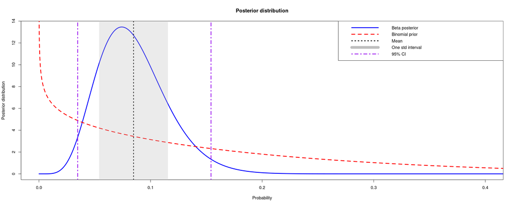

```r
# Plot the results:
plot(probs, post, type = 'l', lwd = 3, col = 'blue', xlab = 'Probability', ylab = 'Posterior distribution', xlim = c(0, 0.4), main = 'Posterior distribution')
lines(probs, prior, type = 'l', lwd = 3, lty = 2, col = 'red')
abline(v = post_mean, col = 'black', lwd = 3, lty = 3)
rect(xleft = post_mean-post_std, xright = post_mean+post_std, ybottom = par("usr")[3], ytop = par("usr")[4], border = NA, col = adjustcolor("grey", alpha = 0.3))
abline(v = c(CI_interval[3], CI_interval[6]), col = 'purple', lwd = 3, lty = 4)
# rect(xleft = CI_interval[3], xright = CI_interval[6], ybottom = par("usr")[3], ytop = par("usr")[4], border = NA, col = adjustcolor("yellow", alpha = 0.3))
legend("topright", legend = c("Beta posterior", "Binomial prior", "Mean", "One std interval", "95% CI"), col = c("blue", "red", "black", "grey", "purple"),
        lty = c(1, 2, 3, 1, 4), lwd = c(3, 3, 3, 10, 3))
```

$\bold{d)}$ To perform a test in order to verify if the probability of failing to detect the disease in an ill patient is grater or equal to $15\%$, I have to assume this null hypothesis and then judge it with a $5\%$ significancy level.

For the Bayesian approach I take the null hypothesis: $$H_0 : p_0 \geq 0.15$$

Which means that, the opposite hypothesis is: $$H_0 : p_0 < 0.15$$

And, we want then to see if the test is better than the previous one. In this point I analyze the Bayesian approach, which means that I have to evaluate $P(H_0|\text{posterior})$. Practically speaking it means that I have to evaluate the integral (or summation in this case) from the null hypothesis to 1 and see wheter it is greater than the significance or not.

```r
# Definition of the parameters
p_test = 0.15
significance = 0.05

# Now I sum the contributes to evaluate the integral
init = p_test/step
fin = as.numeric(1/step)
integral = sum(post[init:fin]*step)
cat("Integral = ", integral, "\n")

# Decide wheter or not to accept the hypothesis
if (integral < significance) {
    cat("The null hypothesis is rejected with significance", significance*100, "%\n")
} else {
    cat("The null hypothesis cannot be rejected with significance", significance*100, "%\n")
}
```

[output not shown]

For completeness I present the results in a plot

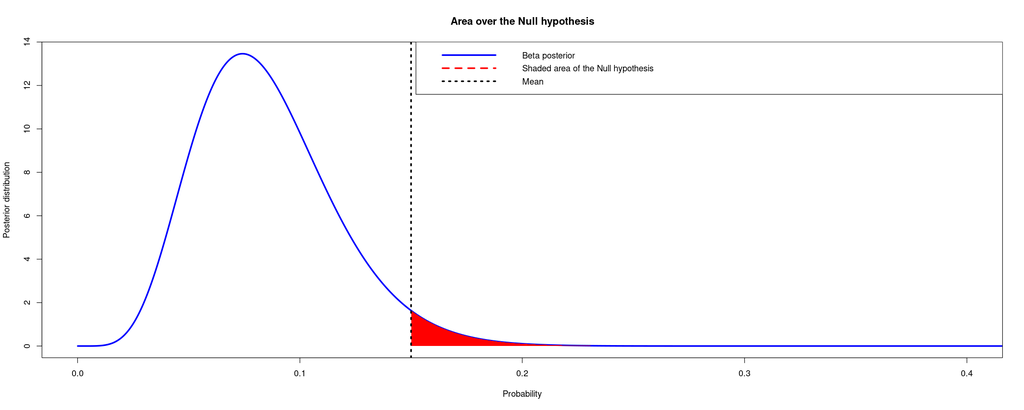

```r
# Plot the results:
plot(probs, post, type = 'l', lwd = 3, col = 'blue', xlab = 'Probability', ylab = 'Posterior distribution', xlim = c(0, 0.4), main = 'Area over the Null hypothesis')
polygon(c(p_test, probs[probs>p_test]), c(0, post[probs>p_test]), col = "red", border = NA)
abline(v = p_test, col = 'black', lwd = 3, lty = 3)
legend("topright", legend = c("Beta posterior", "Shaded area of the Null hypothesis", "Mean"), col = c("blue", "red", "black"),
        lty = c(1, 2, 3), lwd = c(3, 3, 3))
```

This means that, since the probability of having $p>15\%$ is less than the significance, which means that I can reject the Null hypothesis with a significance of $5\%$ and therefore this new test is better than the previous one.

$\bold{e)}$ Similarly to what done in the bayesian way, I can perform a similar analysis using the frequentist approach

```r
# In the frequentist approach it is very easy to find the result, passing through the p-value
p_test = 0.15
significance = 0.05

# The p-value is then defined as
less_values = seq(0, y, 1)
p_value = sum(dbinom(less_values, size = n, p = p_test))

cat("p-value =", p_value, "\n")

if (p_value < significance) {
    cat("The null hypothesis is rejected with significance", significance*100, "%\n")
} else {
    cat("The null hypothesis cannot be rejected with significance", significance*100, "%\n")
}
```

[output not shown]

With this new approach the null hypothesis cannot be rejected: then we cannot say that this new test is better than the other. This means that the acceptance of the hypothesis strongly depends on the approach adopted

# Exercise 3

Given the problem of the lighthouse discussed in class last week, study the case in which both the position along the shore ($\alpha$) and the distance out at sea ($\beta$) are unknown

Before analyzing the problem I see that, from the theory, given the position of the lighthouse indicated with $\alpha_0, \beta_0$ and the number of sampled data $n$, the process has a natural a Cauchy distribution, given by the parametrization of the space, that I can write as:

$$ P(x_k|\alpha, \beta) = P(\theta|\alpha, \beta) \left| \frac{d\theta}{dx_k} \right| = \frac{1}{\pi} \frac{\beta}{\beta^2 + (x_k - \alpha)^2} $$

This distribution results to have an expected maximum at $\alpha$ and an expected FWHM of $2\beta$.

Since then we can assume an uniform prior due to the randomness of the light emission, also the posterior for every single event must result to be a Cauchy distribution. This means that the total posterior distribution is proportional to the product of the various likelihood: therefore be proportional to $\prod_k P(x_k|\alpha, \beta)$. Due to the presence of the product of the distributions it is usually easier to take into account the logarithm of the total posterior instead, leading to:

$$ L = \text{log} \left(P(x_k|\alpha, \beta)\right) = \sum_k \text{log} \left(\frac{\beta}{\beta^2 + (x_k - \alpha)^2}\right) $$

I can then define the parameters needed and the data acquired with the Cauchy distribution

```r
# Setting the seed for reproducibility
set.seed(12)

# Then I assign the parameters given in the slides
alpha_sig = 1
beta_sig = 1

# And then use the seed to generate the data
n_data = 100 # As given in the exercise in class
measurements = rcauchy(n_data, alpha_sig, beta_sig)

# I define also the range at which the two distances have to be searched in
alpha_range = c(-2, 2)
beta_range = c(0, 2)

# And in the end the resolution over those positions
delta_alpha = 0.01; delta_beta = 0.01
alphas = seq(alpha_range[1], alpha_range[2], delta_alpha)
betas = seq(beta_range[1], beta_range[2], delta_beta)
```

Then I can define a function able to fill the matrix containing the values of the posterior for every coulpe of parameters and return the maximum value of the distribution

```r
# Logarithmic posterior to be evaluated for every couple of the parameters
log_post = function (x_k, a, b) {
    return ( sum( log( b / ( b^2 + (x_k-a)^2 ))) )
}

evaluation_problem = function (data, alphas, betas) {

    # First I create a matrix to contain the value of the posterior for every couple of parameters
    post = matrix(data = NA, nrow = length(alphas), ncol = length(betas))

    # And then I allocate the values
    for (i in 1:length(alphas)) {
        for (j in 1:length(betas)) {
                post[i, j] = log_post(data, alphas[i], betas[j])
        }
    }

    # In order to regain the probabilities and not theri logarithm, I have to perfone an exponential
    post = post - max(post, na.rm=TRUE)
    post = exp(post)

    return(post)
}

find_maximum = function (post) {

    # In the end I can retrieve the maximum of the function
    max_index = which(post == max(post, na.rm=TRUE), arr.ind=TRUE)
    max_func = c(alphas[max_index[1]], betas[max_index[2]])

    return(max_func)
}
```

And then I evaluate the posterior varying the number of samples and plotting the conttour function

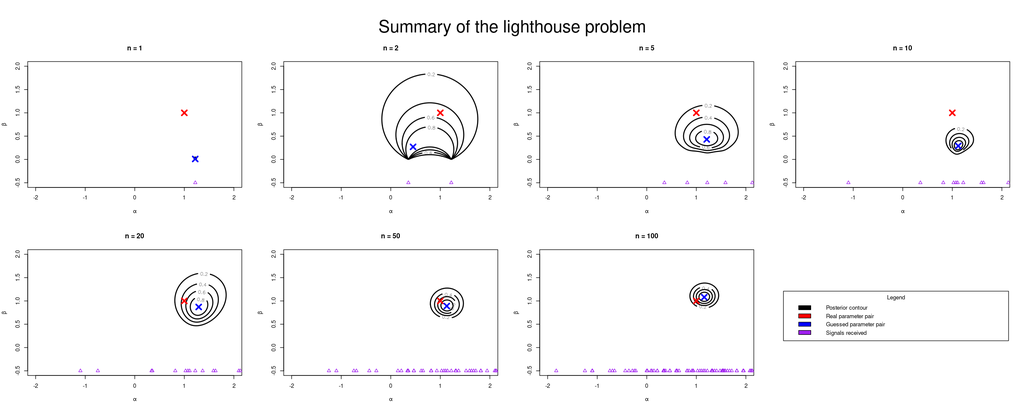

```r
# I loop on the number of measurements, which are given in the lessons slides
n_allowed = c(1, 2, 5, 10, 20, 50, 100)

# And then I can create the plots to be shown
par(mfrow=c(2,4), oma = c(0, 0, 5, 0))
options(repr.plot.width=20, repr.plot.height=8)
pos = -0.5

# Looping on the given number of samples
for (n in n_allowed) {

    # Allocating the posterior values and the maximum of the 2D distribution
    posterior = evaluation_problem(measurements[1:n], alphas, betas)
    maximum = find_maximum(posterior)

    # Creating the contour plot
    contour(x = alphas, y = betas, z = posterior, nlevels = 5, labels = NULL, xlim = alpha_range, ylim = c(beta_range[1] + pos, beta_range[2]), lwd = 2,
            xlab = "α", ylab = "β", main = paste0("n = ", n))

    # And then adding the position of the alpha, beta that generated data and the one corresponding to the max
    points(alpha_sig, beta_sig, pch = 4, lwd = 3, cex = 2, col = "red")
    points(maximum[1], maximum[2], pch = 4, lwd = 3, cex = 2, col = "blue")

    # For demonstration purpioises I overlap the position of the measured data on the alpha axis
    points(measurements[1:n], seq(pos, pos, length.out = n), pch = 2, col = "purple")
}

# In the end I add a legend to understand the data
mtext("Summary of the lighthouse problem", outer = TRUE, cex = 2, font = 1)
par(mai=c(0,0,0,0)); plot.new()
legend("center", ncol = 1, legend = c("Posterior contour", "Real parameter pair", "Guessed parameter pair", "Signals received"),
        fill = c("black", "red", "blue", "purple"), title = "Legend", cex = 1)
```

One can easily see that the predicted couple of parameters tend to the real one for a large number of samples

# Exercise 4

Given the Signal over Background example discussed last week, analyze and discuss the following cases:

(a) vary the sampling resolution of used to generate the data, keeping the same sampling range, using the function

```
xdat <- seq(from=-7*w, to=7*w, by=0.5*w)
```

- change the resolution w = {0.1, 0.25, 1, 2, 3}
- Check the effect on the results

(b) change the ratio A/B used to simulate the data (keeping both positive in accordance with the prior). Check the effect on the results

$\bold{a)}$ First I declare the function to be followed by the signal + background function, which is a rigid transformation of a gaussian centered in the emission value. Then I generate the data and overlap the real distribution over the data, for every value of the resolution given

```r
# I create the samples using the Signal over Background function, defined as:
signal_background = function (x, mu, sigma, A, B, dt) {
    return(dt*(A*exp(-(x-mu)^2/(2*sigma^2)) + B))
}
```

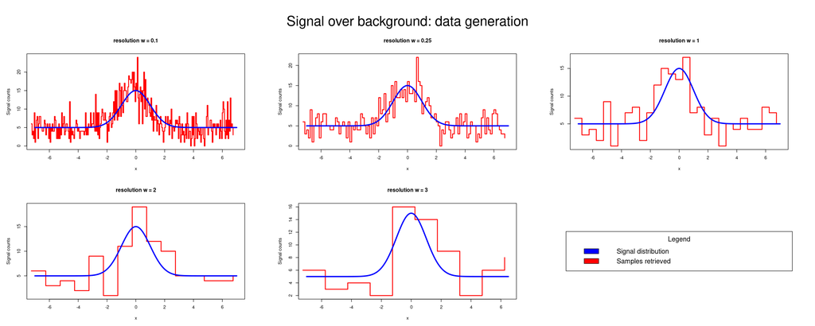

```r
# In order to perform an analysis I perform a for loop in the suggested range
options(repr.plot.width=20, repr.plot.height=8)
par(mfrow=c(2,3), oma = c(0, 0, 5, 0))

# I declare then the parameters of the analisys
mu = 0; A = 2; B = 1; dt = 5; sigma = 1
w_list = c(0.1, 0.25, 1, 2, 3)

# Then I loop on the sampling range
for (w in w_list) {

    # I can generate the data according to the new sampling range "w"
    set.seed(13)
    x = seq(from=-7, to=7, by=0.5*w)
    signal = signal_background(x, mu, sigma, A, B, dt)
    observed = rpois(length(signal), signal)
    x_obs = x - 0.25 # In order to center the histograms

    # And then I add the data distribution
    x_real = seq(from = min(x), to = max(x), by = 0.05*sigma)
    y_real = signal_background(x_real, mu, sigma, A, B, dt)

    # Then I create a plot after shifting the x axis
    par(mar = c(5, 5, 5, 5)) # Modify space for second y-axis: mar = c(down, left, up, right)
    plot(x_obs, observed, type='s', col='red', lwd=2, xlim=range(x), ylim=range(c(y_real, observed)), xlab='x', ylab='Signal counts')
    points(x_real, y_real, type='l', col='blue', lwd=3)
    title(main=(paste0('resolution w = ', w)))
}

# In the end I add a legend to understand the data
mtext("Signal over background: data generation", outer = TRUE, cex = 2, font = 1)
par(mai=c(0,0,0,0)); plot.new()
legend("center", ncol = 1, legend = c("Signal distribution", "Samples retrieved"), fill = c("blue", "red"), title = "Legend", cex = 1.5)
```

And here I can see that the presence of a smaller resolution leads to a better behaviour of the data analysis: the peak is in facts easier to be seen w.r.t. the background. Now I can perform a posterior evaluation, using again the contour function

```r
# As first I have to declare the logrithm of the posterior function (as calculated in the slides)
log.post <- function (d, x, a, b, x0, w, t) {
    if(a<0 || b<0) {
        return(-Inf)
    } else {
        sum( dpois(d, lambda=signal_background(x, mu, w, a, b, dt), log=TRUE) )
    }
}

# Since now I have to create many contour plots I write a function
contour_function = function (w, A, B, title) {

    # Yet known parameters worth evaluating again
    mu = 0; dt = 5
    set.seed(13)
    x = seq(from=-7, to=7, by=0.5*w)
    signal = signal_background(x, mu, w, A, B, dt)
    observed = rpois(length(signal), signal)

    # Then I create the matrix for the creation of the posterior
    N_samples = 100; delta_A = 2; delta_B = 0.4
    a_discretized = seq(A-delta_A, A+delta_A, length.out = N_samples)
    b_discretized = seq(B-delta_B, B+delta_B, length.out = N_samples)
    posterior = matrix(data = NA, nrow = length(a_discretized), ncol = length(b_discretized))

    # And then I allocate the value of the posterior
    for (i in 1:length(a_discretized)) {
        for (j in 1:length(b_discretized)) {
            posterior[i, j] = log.post(observed, x, a_discretized[i], b_discretized[j], mu, w, dt)
        }
    }

    # Allocating the maximum of the 2D distribution
    max_index = which(posterior == max(posterior, na.rm=TRUE), arr.ind=TRUE)
    maximum = c(a_discretized[max_index[1]], b_discretized[max_index[2]])
    posterior = posterior - max(posterior)

    # Creating the contour plot
    pos = -0.1
    contour(x = a_discretized, y = b_discretized, z = exp(posterior), nlevels = 5, labels = NULL, xlim = c(A-delta_A, A+delta_A), ylim = c(B-delta_B + pos, B+delta_B),
            lwd = 2, xlab = "Amplitude A", ylab = "Background B", main=title)

    # And then adding the position of the alpha, beta that generated data and the one corresponding to the max
    points(A, B, pch = 4, lwd = 3, cex = 2, col = "red")
    points(maximum[1], maximum[2], pch = 4, lwd = 3, cex = 2, col = "blue")

}
```

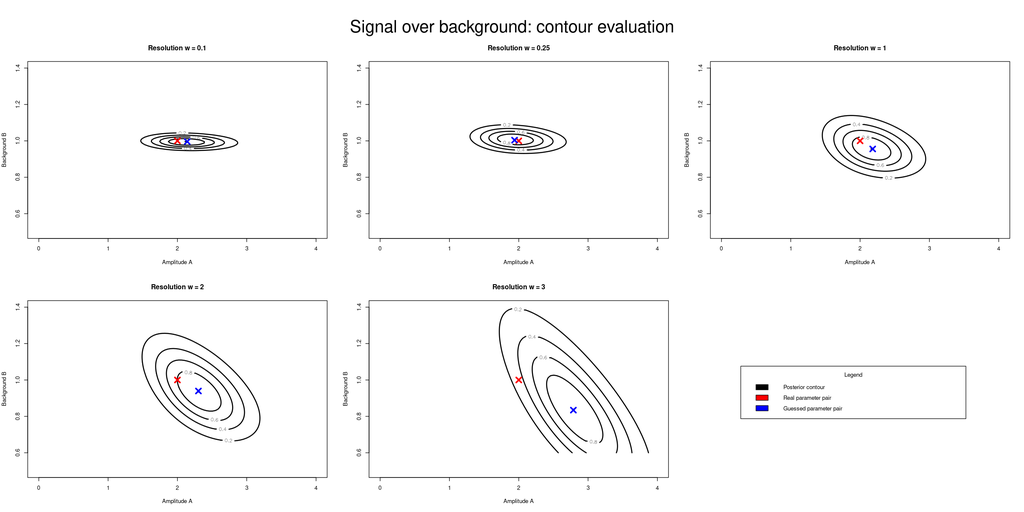

```r
# Now I can loop on the values and then plot
options(repr.plot.width=20, repr.plot.height=10)
par(mfrow=c(2,3), oma = c(0, 0, 5, 0))

mu = 0; A = 2; B = 1; dt = 5; sigma = 1

for (w in w_list) {
    contour_function(w, A, B, title = paste0("Resolution w = ", w))
}

# In the end I add a legend to understand the data
mtext("Signal over background: contour evaluation", outer = TRUE, cex = 2, font = 1)
par(mai=c(0,0,0,0)); plot.new()
legend("center", ncol = 1, legend = c("Posterior contour", "Real parameter pair", "Guessed parameter pair"),
fill = c("black", "red", "blue"), title = "Legend", cex = 1)
```

$\bold{b)}$ Now I have to change the ratio between $A$ and $B$ in order to see how the signal is modified:

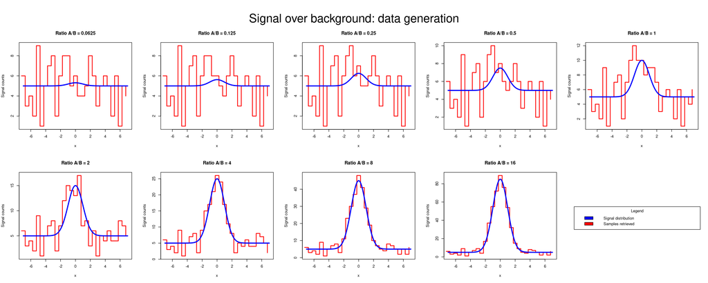

```r
# I perform the same analysis done on the previous piece of code, but now the idea is to change the ratio A/B, therefore I create a function
options(repr.plot.width=20, repr.plot.height=8)
par(mfrow=c(2,5), oma = c(0, 0, 5, 0))

# I declare then the parameters of the analisys
mu = 0; B = 1; dt = 5; sigma = 1
ratios = c(2**-4, 2**-3, 2**-2, 2**-1, 1, 2, 2**2, 2**3, 2**4)

# Then I loop on the sampling range
for (r in ratios) {
    # New parameter
    A = B*r

    # I can generate the data according to the new sampling range "w"
    set.seed(13)
    x = seq(from=-7, to=7, by=0.5*sigma)
    signal = signal_background(x, mu, sigma, A, B, dt)
    observed = rpois(length(signal), signal)
    x_obs = x - 0.25 # In order to center the histograms

    # And then I add the data distribution
    x_real = seq(from = min(x), to = max(x), by = 0.05*sigma)
    y_real = signal_background(x_real, mu, sigma, A, B, dt)

    # Then I create a plot after shifting the x axis
    plot(x_obs, observed, type='s', col='red', lwd=2, xlim=range(x), ylim=range(c(y_real, observed)), xlab='x', ylab='Signal counts')
    points(x_real, y_real, type='l', col='blue', lwd=3)
    title(main=(paste0('Ratio A/B = ', r)))
}

# In the end I add a legend to understand the data
mtext("Signal over background: data generation", outer = TRUE, cex = 2, font = 1)
par(mai=c(0,0,0,0)); plot.new()
legend("center", ncol = 1, legend = c("Signal distribution", "Samples retrieved"), fill = c("blue", "red"), title = "Legend", cex = 1)
```

Using the function defined before I evaluate the contour behaviour over the two parameters:

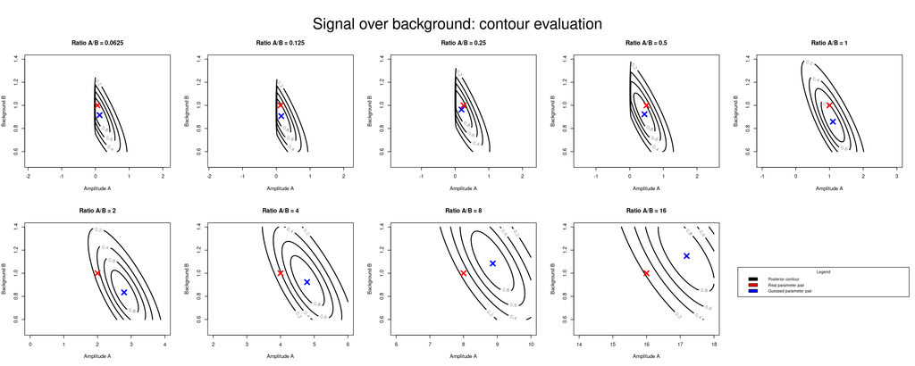

```r
# Now I can loop on the values and then plot
options(repr.plot.width=20, repr.plot.height=8)
par(mfrow=c(2,5), oma = c(0, 0, 5, 0))

mu = 0; A = 2; B = 1; dt = 5; sigma = 1

for (r in ratios) {
    A = B*r
    contour_function(w, A, B, title = paste0("Ratio A/B = ", r))
}

# In the end I add a legend to understand the data
mtext("Signal over background: contour evaluation", outer = TRUE, cex = 2, font = 1)
par(mai=c(0,0,0,0)); plot.new()
legend("center", ncol = 1, legend = c("Posterior contour", "Real parameter pair", "Guessed parameter pair"),
fill = c("black", "red", "blue"), title = "Legend", cex = 0.8)
```

Here I see that the guessed parameter pair is better for a low ratio $\frac{A}{B}$, with a probability that goes to zero. On the other way around, for an increasing ratio, the probability goes to zero, as expected from the theory. I underline the fact that the probability falls to $-\infty$ as soon as one of the two parameters goes to zero, which in our case is $A$